# Epigenetic model only

### CV and SHAP analysis

optimised parameters (n_estimators = 10k, n_leaves=50) random seed = 8 for shuffling

```python
import lightgbm as lgb
from sklearn.model_selection import train_test_split, cross_validate, cross_val_predict
from sklearn.metrics import mean_squared_error, r2_score
from sklearn.utils import shuffle
from sklearn.ensemble import RandomForestRegressor
from scipy.stats import pearsonr
import matplotlib.pyplot as plt
import seaborn as sns

import shap
import pandas as pd
import numpy as np
# print the JS visualization code to the notebook
shap.initjs()
```

## Read in and process data

```python
rna = pd.read_table("../data/RNA_CPM_logFC_all_DEG_promoters.tsv", index_col=0)
rna["i"] = range(len(rna.index))
rna["abs_logfc"] = abs(rna["logratio"])
rna.columns
```

```
Index(['Chr', 'Start', 'End', 'Strand', 'beige', 'white', 'logratio',
       'transcript_id', 'transcript_biotype', 'ensembl_gene_id', 'gene_name',
       'gene_biotype', 'promoter_start', 'promoter_end', 'promoter_id.1', 'i',
       'abs_logfc'],
      dtype='object')
```

```python
rna.drop_duplicates().shape
print(sum(rna.index.duplicated()))
```

```
0
```

```python
rna = rna.assign(avg_expr = (rna["beige"] + rna["white"])/2)
rna.head()
```

| promoter_id | Chr | Start | End | Strand | beige | white | logratio | transcript_id | transcript_biotype | ensembl_gene_id | gene_name | gene_biotype | promoter_start | promoter_end | promoter_id.1 | i | abs_logfc | avg_expr |
| --- | --- | --- | --- | --- | --- | --- | --- | --- | --- | --- | --- | --- | --- | --- | --- | --- | --- | --- |
| chr10:100329640:100331940 | chr10 | 100329641 | 100329940 | - | 0.160466 | 0.408177 | -0.156598 | ENST00000528248.1 | nonsense_mediated_decay | ENSG00000107593 | PKD2L1 | protein_coding | 100329640 | 100331940 | chr10:100329640:100331940 | 0 | 0.156598 | 0.284321 |
| chr10:100329672:100331972 | chr10 | 100329673 | 100329972 | - | 0.177564 | 0.458265 | -0.174925 | ENST00000465680.2 | protein_coding | ENSG00000107593 | PKD2L1 | protein_coding | 100329672 | 100331972 | chr10:100329672:100331972 | 1 | 0.174925 | 0.317915 |
| chr10:100329928:100332228 | chr10 | 100329929 | 100330228 | - | 0.241227 | 0.781271 | -0.311455 | ENST00000318222.4 | protein_coding | ENSG00000107593 | PKD2L1 | protein_coding | 100329928 | 100332228 | chr10:100329928:100332228 | 2 | 0.311455 | 0.511249 |
| chr10:100329964:100332264 | chr10 | 100329965 | 100330264 | - | 0.239160 | 0.744577 | -0.293626 | ENST00000532547.1 | nonsense_mediated_decay | ENSG00000107593 | PKD2L1 | protein_coding | 100329964 | 100332264 | chr10:100329964:100332264 | 3 | 0.293626 | 0.491868 |
| chr10:100986896:100989196 | chr10 | 100986897 | 100987196 | - | 16.805497 | 2.700954 | 2.000129 | ENST00000523148.5 | protein_coding | ENSG00000055950 | MRPL43 | protein_coding | 100986896 | 100989196 | chr10:100986896:100989196 | 4 | 2.000129 | 9.753226 |

```python
y = rna["logratio"]
print(y.shape) #1D array, good
y.head()
```

```
(18282,)
```

```
promoter_id
chr10:100329640:100331940   -0.156598
chr10:100329672:100331972   -0.174925
chr10:100329928:100332228   -0.311455
chr10:100329964:100332264   -0.293626
chr10:100986896:100989196    2.000129
Name: logratio, dtype: float64
```

```python
len(rna)/100
```

```
182.82
```

```python
epi = pd.read_table( "../data/epigenetic_tracks_day15_logFC.tsv", index_col=0)
epi = epi.iloc[:,0:7]
epi.head()
```

| promoter_id | atac_logfc | H3K27ac | H3K27me3 | H3K36me3 | H3K4me1 | H3K4me3 | H3K9me3 |
| --- | --- | --- | --- | --- | --- | --- | --- |
| chr10:100329640:100331940 | 0.183250 | 0.406192 | -0.577472 | 0.339955 | 0.187522 | 0.139724 | -0.081256 |
| chr10:100329672:100331972 | 0.184638 | 0.415668 | -0.580600 | 0.355348 | 0.205285 | 0.134421 | -0.095082 |
| chr10:100329928:100332228 | 0.187500 | 0.421045 | -0.509048 | 0.371277 | 0.185287 | 0.122751 | -0.101734 |
| chr10:100329964:100332264 | 0.187884 | 0.417634 | -0.500510 | 0.362101 | 0.172796 | 0.114894 | -0.075076 |
| chr10:100986896:100989196 | 0.234081 | 0.111826 | 0.129987 | 0.017680 | 0.407064 | 0.688711 | 0.089414 |

```python
print(epi.columns)
print(epi.shape)
```

```
Index(['atac_logfc', 'H3K27ac', 'H3K27me3', 'H3K36me3', 'H3K4me1', 'H3K4me3',
       'H3K9me3'],
      dtype='object')
(18282, 7)
```

# Step1: Train the model

```python
# set up model to run
estimator = lgb.LGBMRegressor(
    max_bin=512, #default 255
    n_estimators = 10000, #default 100 but we need more
    learning_rate=0.05,
    boosting_type= "gbdt",
    objective= "regression",
    metric= "mean_squared_error",
    num_leaves= 50,
    verbose= -1,
    min_data= 100,
    boost_from_average= True)
#shuffle rows
epi, y = shuffle(epi, y, random_state=8)
```

```python
#output metrics to collect
score_list = ['neg_root_mean_squared_error',#average error in logFC units RMSE
                                    'r2',#coefficent of determination; correlation score
                                    'max_error' #worst case error
                                   ]
```

```python
scores = cross_validate(estimator, epi, y, cv=10,
                       scoring = score_list,
                        return_estimator = True,
                        return_indices = True)
```

```
[Text(1, 0, 'max_error')]
```

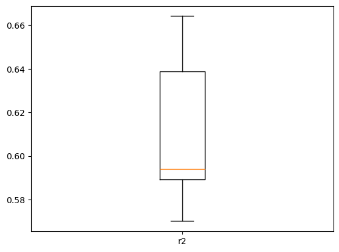

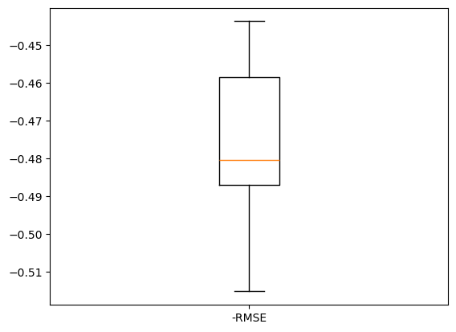

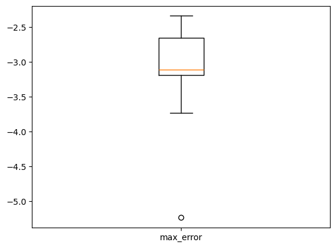

```python
gif, ax = plt.subplots()
ax.boxplot(scores["test_r2"])
ax.set_xticklabels(['r2'])

gif, ax = plt.subplots()
ax.boxplot(scores["test_neg_root_mean_squared_error"])
ax.set_xticklabels(['-RMSE'])

gif, ax = plt.subplots()
ax.boxplot(scores["test_max_error"])
ax.set_xticklabels(['max_error'])
```

```
   A6H_7_fit_time  A6H_7_rmse  A6H_7_r2  A6H_7_max_error
0       31.760006   -0.457470  0.595922        -2.337018
1       23.278834   -0.487757  0.570086        -3.116755
2       29.946892   -0.515100  0.585942        -5.233966
3       34.424716   -0.484389  0.590640        -3.167941
4       35.575330   -0.484716  0.626804        -3.192072
```

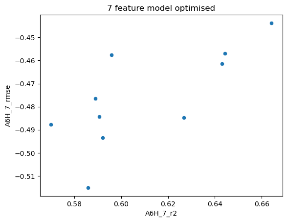

```python
sdict = {}
model_name = "A6H_7"
sdict[model_name +"_fit_time"] = scores["fit_time"]
for s in score_list:
    if s == "neg_root_mean_squared_error":
        short_name = "rmse"
    else:
        short_name = s
    sdict[model_name + "_" + short_name] = scores["test_"+s]


sdf = pd.DataFrame(sdict)
print(sdf.head())
sns.scatterplot(sdf, x='A6H_7_r2', y='A6H_7_rmse').set_title("7 feature model optimised");
```

```python
sdf.to_csv("../output/A6H_7_optimised_params.tsv", sep="\t", index=False)
```

# Model predictions and error per TSS

```python
y_pred = cross_val_predict(estimator, epi, y, cv=10)
```

```python
print(y_pred[0:10])
y[0:10]
```

```
[-1.07685864 -0.1326604  -0.02446613  0.45643427 -0.61369342  0.0095106
 -0.06324081  0.47081064  0.37067963 -0.07033477]
```

```
promoter_id
chr2:111494786:111497086   -1.107927
chr9:98375007:98377307      0.000000
chr16:12899619:12901919     0.000000
chr16:57802634:57804934     0.000000
chr16:57802953:57805253     0.000000
chr17:3557467:3559767       0.000000
chr8:127852708:127855008   -0.008390
chr10:58510871:58513171     0.012191
chr12:89349014:89351314     0.840021
chr17:31320732:31323032     0.000000
Name: logratio, dtype: float64
```

```python
residuals = y_pred - y
residuals = residuals.rename("prediction_error")
```

```python
prediction = pd.DataFrame({"logfc":y,"pred_logfc":y_pred,"prediction_error":residuals})
prediction.to_csv("../output/residuals_A6H_7_optimised_params.tsv", sep="\t", index=True)
prediction.head()
```

| promoter_id | logfc | pred_logfc | prediction_error |
| --- | --- | --- | --- |
| chr2:111494786:111497086 | -1.107927 | -1.076859 | 0.031068 |
| chr9:98375007:98377307 | 0.000000 | -0.132660 | -0.132660 |
| chr16:12899619:12901919 | 0.000000 | -0.024466 | -0.024466 |
| chr16:57802634:57804934 | 0.000000 | 0.456434 | 0.456434 |
| chr16:57802953:57805253 | 0.000000 | -0.613693 | -0.613693 |

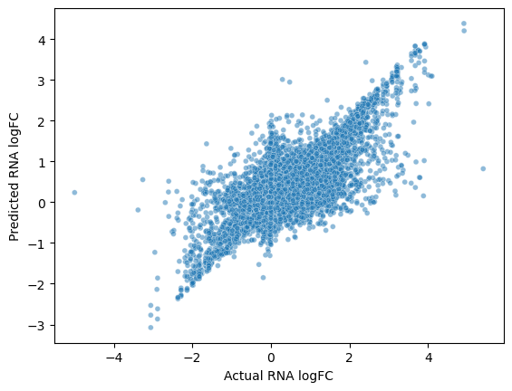

```python
sns.scatterplot(x=y,y=y_pred, alpha=0.5, size=5, legend=False)
plt.xlabel("Actual RNA logFC")
plt.ylabel("Predicted RNA logFC")
```

```python
rna_error = pd.concat([rna, residuals], axis=1)
rna_error["log_avg_expr"] = np.log2( rna_error["avg_expr"] +0.5)
rna_error["abs_error"] = abs(rna_error["prediction_error"])
rna_error.head()
```

| promoter_id | Chr | Start | End | Strand | beige | white | logratio | transcript_id | transcript_biotype | ensembl_gene_id | ... | gene_biotype | promoter_start | promoter_end | promoter_id.1 | i | abs_logfc | avg_expr | prediction_error | log_avg_expr | abs_error |
| --- | --- | --- | --- | --- | --- | --- | --- | --- | --- | --- | --- | --- | --- | --- | --- | --- | --- | --- | --- | --- | --- |
| chr10:100329640:100331940 | chr10 | 100329641 | 100329940 | - | 0.160466 | 0.408177 | -0.156598 | ENST00000528248.1 | nonsense_mediated_decay | ENSG00000107593 | ... | protein_coding | 100329640 | 100331940 | chr10:100329640:100331940 | 0 | 0.156598 | 0.284321 | -0.202837 | -0.350483 | 0.202837 |
| chr10:100329672:100331972 | chr10 | 100329673 | 100329972 | - | 0.177564 | 0.458265 | -0.174925 | ENST00000465680.2 | protein_coding | ENSG00000107593 | ... | protein_coding | 100329672 | 100331972 | chr10:100329672:100331972 | 1 | 0.174925 | 0.317915 | -0.000376 | -0.289978 | 0.000376 |
| chr10:100329928:100332228 | chr10 | 100329929 | 100330228 | - | 0.241227 | 0.781271 | -0.311455 | ENST00000318222.4 | protein_coding | ENSG00000107593 | ... | protein_coding | 100329928 | 100332228 | chr10:100329928:100332228 | 2 | 0.311455 | 0.511249 | 0.191179 | 0.016139 | 0.191179 |
| chr10:100329964:100332264 | chr10 | 100329965 | 100330264 | - | 0.239160 | 0.744577 | -0.293626 | ENST00000532547.1 | nonsense_mediated_decay | ENSG00000107593 | ... | protein_coding | 100329964 | 100332264 | chr10:100329964:100332264 | 3 | 0.293626 | 0.491868 | 0.350834 | -0.011779 | 0.350834 |
| chr10:100986896:100989196 | chr10 | 100986897 | 100987196 | - | 16.805497 | 2.700954 | 2.000129 | ENST00000523148.5 | protein_coding | ENSG00000055950 | ... | protein_coding | 100986896 | 100989196 | chr10:100986896:100989196 | 4 | 2.000129 | 9.753226 | -0.770281 | 3.358006 | 0.770281 |

5 rows × 21 columns

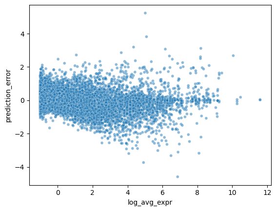

```python
sns.scatterplot(rna_error,x='log_avg_expr',y='prediction_error', alpha=0.5, size=5, legend=False)
```

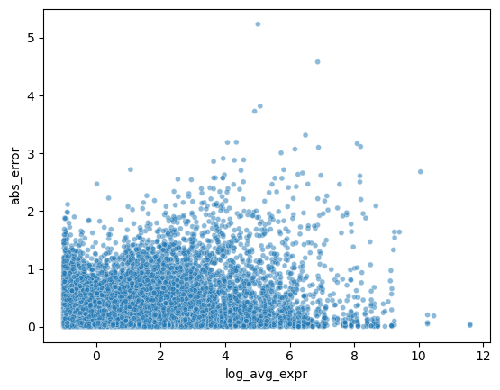

```python
sns.scatterplot(rna_error,x='log_avg_expr',y='abs_error', alpha=0.5, size=5, legend=False)
```

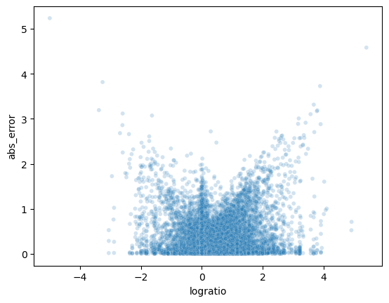

```python
sns.scatterplot(rna_error,x='logratio',y='abs_error', alpha=0.2, size=5, legend=False)
```

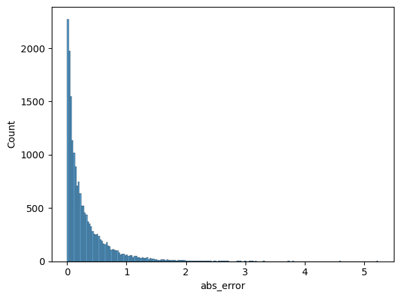

```python
sns.histplot(rna_error, x='abs_error')
```

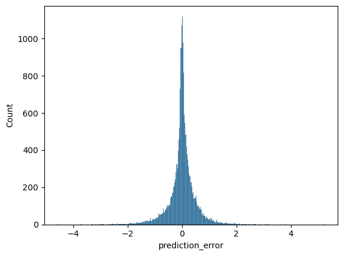

```python
sns.histplot(rna_error, x='prediction_error')
```

# Step2: Explain contributions with SHAP values

Now we get to an interesting point, explanation-wise, each TSS has 9 models were it was in training and 1 where it was test. Does it make a difference, shap-wise whether we use the trained or test model?

Ideally I gues we select a representative model, one with a score/error close to the average or median?

```python
shap_vals_list = []
base_means = []
for fold in range(10):
    model = scores['estimator'][fold]
    X_test = epi.iloc[scores['indices']['test'][fold],]
    print("Fold ",fold, ": ", scores['indices']['test'][fold][[0,-1]])
    explainer = shap.TreeExplainer(model)
    shap_values = explainer(X_test)
    for shaps in shap_values:
        shap_vals_list.append(shaps.values)
        base_means.append(shaps.base_values)
avg_base_mean = np.mean(base_means)
print(avg_base_mean)
```

```
Fold  0 :  [   0 1828]
Fold  1 :  [1829 3657]
Fold  2 :  [3658 5485]
Fold  3 :  [5486 7313]
Fold  4 :  [7314 9141]
Fold  5 :  [ 9142 10969]
Fold  6 :  [10970 12797]
Fold  7 :  [12798 14625]
Fold  8 :  [14626 16453]
Fold  9 :  [16454 18281]
0.30638246319735984
```

```python
shap_values = shap.Explanation(np.array(shap_vals_list), np.array(base_means), np.array(epi))
shap_values.feature_names = epi.columns
shap_values.feature_names
```

```
Index(['atac_logfc', 'H3K27ac', 'H3K27me3', 'H3K36me3', 'H3K4me1', 'H3K4me3',
       'H3K9me3'],
      dtype='object')
```

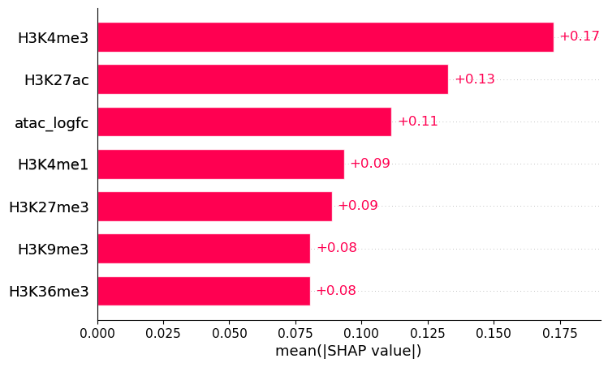

```python
shap.plots.bar(shap_values)
```

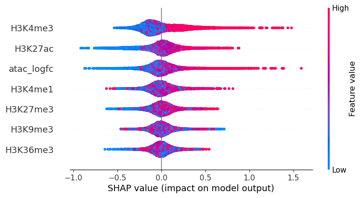

```python
shap.plots.beeswarm(shap_values)
#alias: shap.summary_plot(shap_values)
```

high H3K4me3 logFC can be a good predictor, but many sites of high H3K4me3 have low predictive value (shap value ~0 as well). Does this indicating a second mark is necessary for that prediction? All the other tracks are centred around zero shap values. H3K27ac and ATAC signal are the next highest predictors

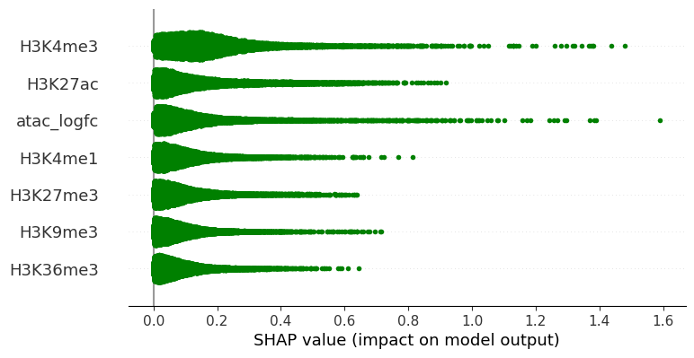

```python
shap.plots.beeswarm(shap_values.abs, color="green")
```

```python
shap_df = pd.DataFrame(shap_values.values, index=epi.index, columns=epi.columns)
shap_df
```

| promoter_id | atac_logfc | H3K27ac | H3K27me3 | H3K36me3 | H3K4me1 | H3K4me3 | H3K9me3 |
| --- | --- | --- | --- | --- | --- | --- | --- |
| chr2:111494786:111497086 | -0.489493 | -0.466994 | -0.111286 | -0.046134 | -0.091745 | -0.169049 | -0.009960 |
| chr9:98375007:98377307 | -0.044454 | -0.181634 | -0.073457 | -0.029470 | 0.023609 | -0.061242 | -0.073815 |
| chr16:12899619:12901919 | 0.003820 | -0.039140 | -0.155667 | -0.118971 | 0.046757 | -0.055743 | -0.013325 |
| chr16:57802634:57804934 | -0.193316 | -0.023710 | 0.136769 | 0.094672 | -0.014915 | 0.025929 | 0.123202 |
| chr16:57802953:57805253 | -0.228531 | -0.152215 | -0.128923 | -0.121518 | 0.021449 | -0.080993 | -0.230764 |
| ... | ... | ... | ... | ... | ... | ... | ... |
| chr17:28723927:28726227 | -0.109545 | -0.080363 | 0.017159 | -0.052215 | -0.003692 | 0.151889 | 0.083876 |
| chr19:1246552:1248852 | -0.115291 | -0.087437 | -0.041501 | -0.070287 | -0.116583 | 0.033014 | 0.072013 |
| chr20:57389452:57391752 | 0.098536 | 0.017080 | 0.033985 | -0.007631 | 0.030923 | 0.091653 | -0.021937 |
| chr12:131826405:131828705 | -0.164156 | 0.062981 | -0.089120 | -0.099331 | 0.026034 | 0.053861 | -0.111025 |
| chr16:3063321:3065621 | 0.055625 | -0.613780 | -0.042276 | -0.024683 | 0.035694 | -0.219535 | -0.110398 |

18282 rows × 7 columns

```python
shap_df.to_csv("../output/shap_A6H_7_optimised_params.tsv", sep="\t", index=True)
```

```python
import pickle
filename = "../output/shap_A6H_7_optimised_params.sav"

pickle.dump(shap_values, open(filename, 'wb'))
```

## Adding clustering info post-hoc

```python
clusters = shap.utils.hclust(epi, y)
clusters
```

```
array([[ 0.        ,  1.        ,  0.70352364,  2.        ],
       [ 5.        ,  7.        ,  0.90485293,  3.        ],
       [ 2.        ,  8.        ,  0.93106103,  4.        ],
       [ 4.        ,  9.        ,  0.94735169,  5.        ],
       [ 3.        , 10.        ,  0.98782903,  6.        ],
       [ 6.        , 11.        ,  0.98864436,  7.        ]])
```

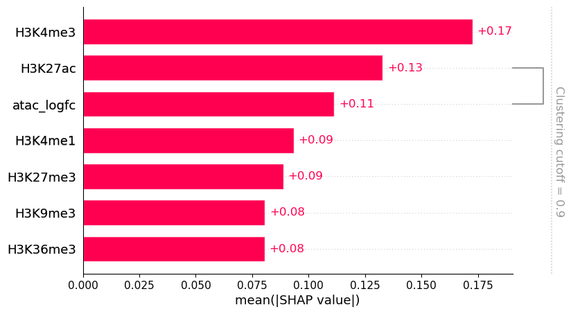

```python
shap.plots.bar(shap_values, clustering=clusters, clustering_cutoff=0.90)
```

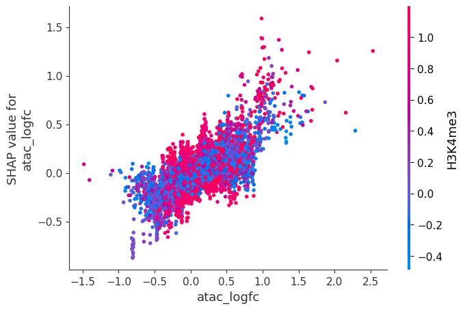

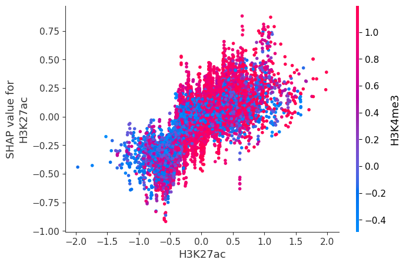

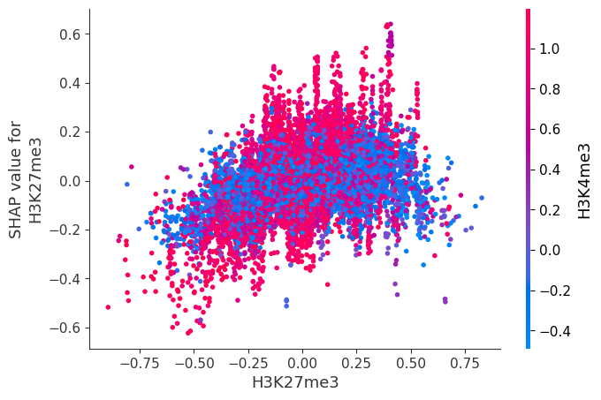

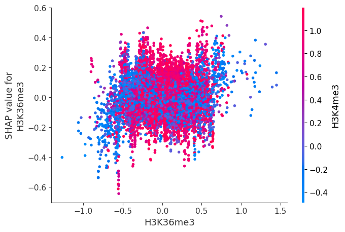

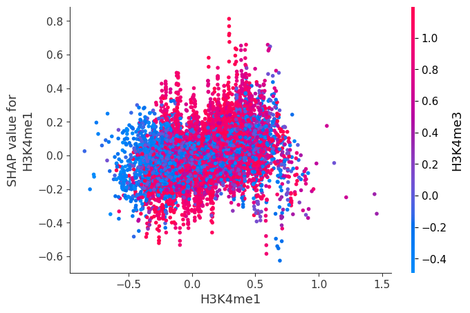

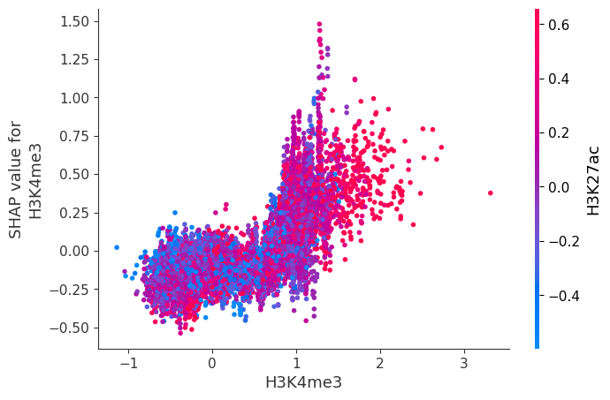

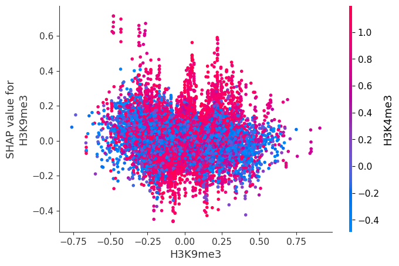

```python
for name in epi.columns:
    shap.dependence_plot(name, shap_values.values, epi)
```

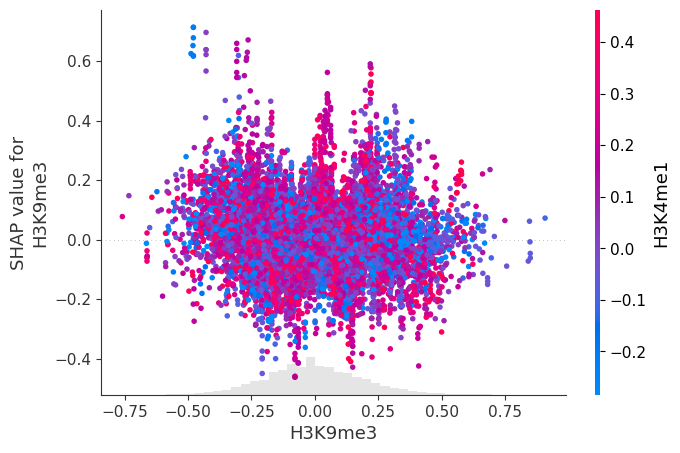

```python
shap.plots.scatter(shap_values[:,"H3K9me3"], color=shap_values[:,"H3K4me1"])
```

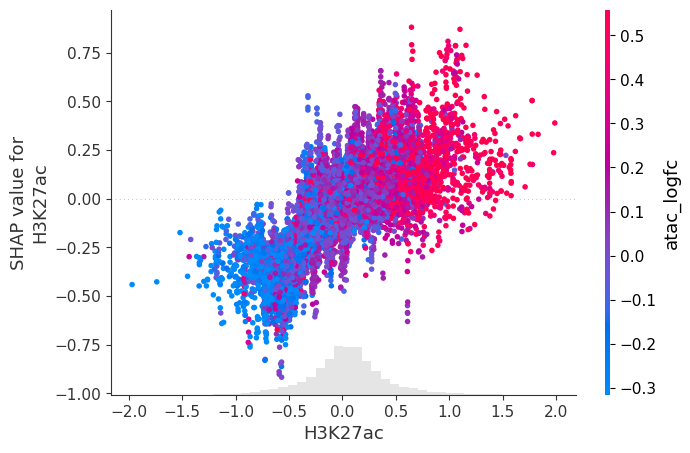

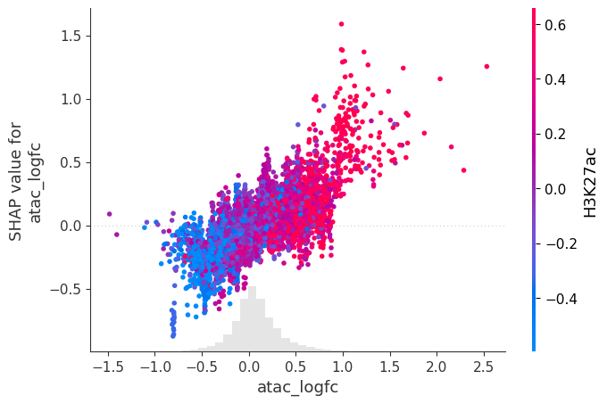

```python
shap.plots.scatter(shap_values[:,"H3K27ac"], color=shap_values[:,"atac_logfc"])
shap.plots.scatter(shap_values[:,"atac_logfc"], color=shap_values[:,"H3K27ac"])
```

ATAC and H3K27ac shap values and track levels are correlated. H3K4me3 however is only correlated with these marks for very high logFC.

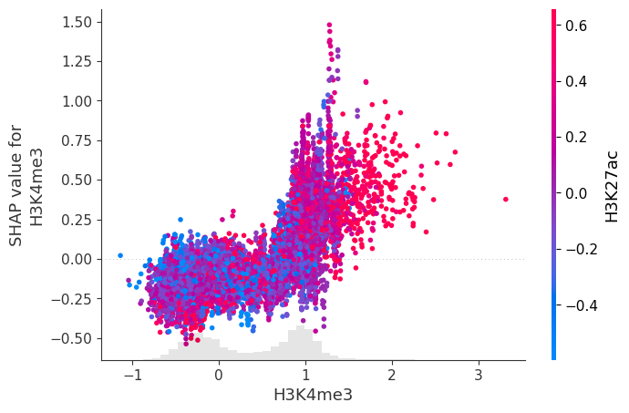

```python
shap.plots.scatter(shap_values[:,"H3K4me3"], color=shap_values[:,"H3K27ac"])
```

```
(-1.0, 1.5)
```

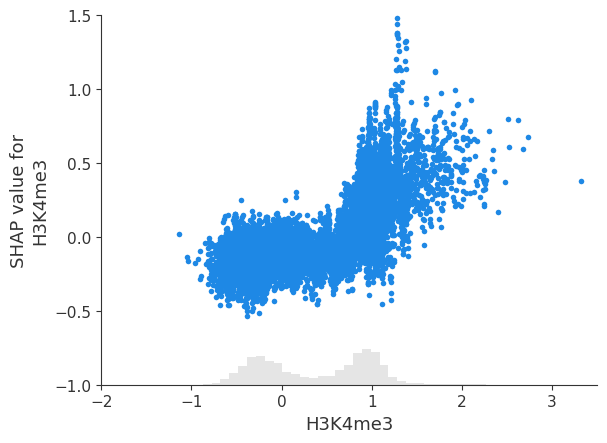

```python
fig, ax = plt.subplots()
scatter = shap.plots.scatter(shap_values[:,"H3K4me3"], ax=ax, show=False)
ax.set_xlim([-2,3.5]);
ax.set_ylim([-1,1.5])
```

```
(-1.0, 1.5)
```

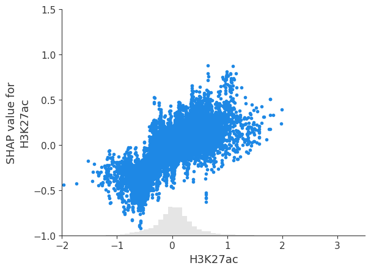

```python
fig, ax = plt.subplots()
scatter = shap.plots.scatter(shap_values[:,"H3K27ac"], ax=ax, show=False)
ax.set_xlim([-2,3.5]);
ax.set_ylim([-1,1.5])
```

```
(-1.0, 1.5)
```

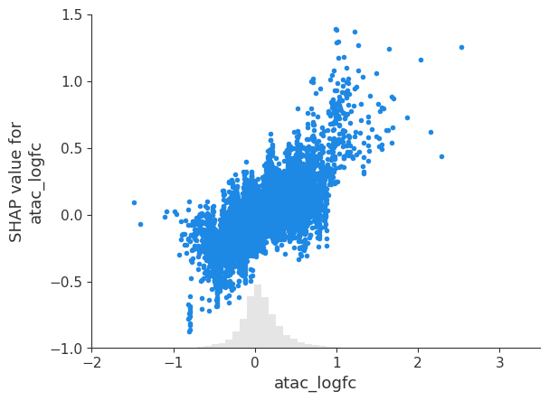

```python
fig, ax = plt.subplots()
scatter = shap.plots.scatter(shap_values[:,"atac_logfc"], ax=ax, show=False)
ax.set_xlim([-2,3.5]);
ax.set_ylim([-1,1.5])
```

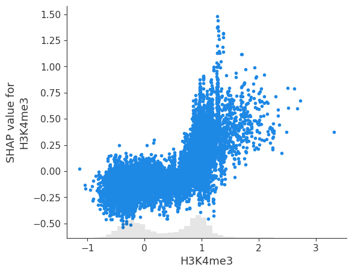

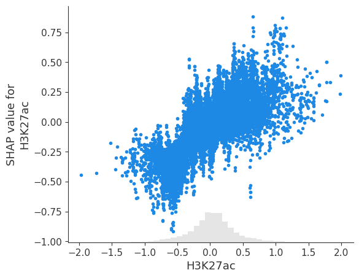

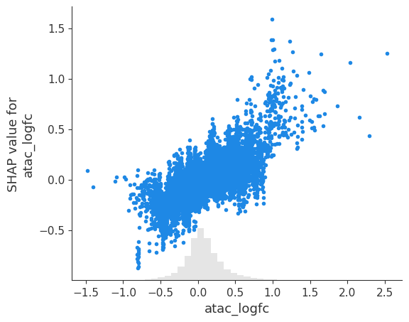

```python
shap.plots.scatter(shap_values[:,"H3K4me3"])
shap.plots.scatter(shap_values[:,"H3K27ac"])
shap.plots.scatter(shap_values[:,"atac_logfc"])
```

## Looking at top genes

```python
#Need an index column on RNA to select paricular genes from the shap output
#input to model is promoter_id sorted like this
#also useful to sort by absolute logratio so we can autoselect biggest differences
rna= rna.sort_values("abs_logfc", ascending=False)
rna.head()
```

| promoter_id | Chr | Start | End | Strand | beige | white | logratio | transcript_id | transcript_biotype | ensembl_gene_id | gene_name | gene_biotype | promoter_start | promoter_end | promoter_id.1 | i | abs_logfc | avg_expr |
| --- | --- | --- | --- | --- | --- | --- | --- | --- | --- | --- | --- | --- | --- | --- | --- | --- | --- | --- |
| chr16:88657207:88659507 | chr16 | 88657208 | 88657507 | - | 229.200017 | 3.464493 | 5.402910 | ENST00000565720.1 | lncRNA | ENSG00000167508 | MVD | protein_coding | 88657207 | 88659507 | chr16:88657207:88659507 | 5144 | 5.402910 | 116.332255 |
| chr1:101786919:101789219 | chr1 | 101786920 | 101787219 | - | 0.058524 | 63.700108 | -4.996214 | ENST00000431241.1 | processed_pseudogene | ENSG00000183298 | RPSAP19 | processed_pseudogene | 101786919 | 101789219 | chr1:101786919:101789219 | 8608 | 4.996214 | 31.879316 |
| chr20:45911855:45914155 | chr20 | 45911856 | 45912155 | - | 78.875952 | 0.676490 | 4.917297 | ENST00000372431.8,ENST00000420868.2 | protein_coding | ENSG00000100979 | PLTP | protein_coding | 45911855 | 45914155 | chr20:45911855:45914155 | 10340 | 4.917297 | 39.776221 |
| chr20:45911852:45914152 | chr20 | 45911853 | 45912152 | - | 78.877846 | 0.687756 | 4.911270 | ENST00000354050.8 | protein_coding | ENSG00000100979 | PLTP | protein_coding | 45911852 | 45914152 | chr20:45911852:45914152 | 10339 | 4.911270 | 39.782801 |
| chr8:19936869:19939169 | chr8 | 19938870 | 19939169 | + | 78.222729 | 2.676144 | 4.100620 | ENST00000524029.5 | protein_coding | ENSG00000175445 | LPL | protein_coding | 19936869 | 19939169 | chr8:19936869:19939169 | 16775 | 4.100620 | 40.449436 |

```python
y_index = pd.Series(range(len(y.index)), index=y.index, name="shuffle_i")
print(y_index)
y_index = pd.DataFrame(y_index)
y_index["pred_logfc"] = y_pred
y_index = rna.join(y_index)
```

```
promoter_id
chr2:111494786:111497086         0
chr9:98375007:98377307           1
chr16:12899619:12901919          2
chr16:57802634:57804934          3
chr16:57802953:57805253          4
                             ...
chr17:28723927:28726227      18277
chr19:1246552:1248852        18278
chr20:57389452:57391752      18279
chr12:131826405:131828705    18280
chr16:3063321:3065621        18281
Name: shuffle_i, Length: 18282, dtype: int64
```

```python
print(y_index)
```

```
                            Chr      Start        End Strand       beige  \
promoter_id
chr16:88657207:88659507   chr16   88657208   88657507      -  229.200017
chr1:101786919:101789219   chr1  101786920  101787219      -    0.058524
chr20:45911855:45914155   chr20   45911856   45912155      -   78.875952
chr20:45911852:45914152   chr20   45911853   45912152      -   78.877846
chr8:19936869:19939169     chr8   19938870   19939169      +   78.222729
...                         ...        ...        ...    ...         ...
chr2:231035561:231037861   chr2  231037562  231037861      +    0.000000
chr16:19209156:19211456   chr16   19211157   19211456      +    0.000000
chr17:75523079:75525379   chr17   75525080   75525379      +    0.000000
chr2:231035522:231037822   chr2  231037523  231037822      +    0.000000
chr1:146401347:146403647   chr1  146401348  146401647      -    0.000000

                              white  logratio  \
promoter_id
chr16:88657207:88659507    3.464493  5.402910
chr1:101786919:101789219  63.700108 -4.996214
chr20:45911855:45914155    0.676490  4.917297
chr20:45911852:45914152    0.687756  4.911270
chr8:19936869:19939169     2.676144  4.100620
...                             ...       ...
chr2:231035561:231037861   0.000000  0.000000
chr16:19209156:19211456    0.000000  0.000000
chr17:75523079:75525379    0.000000  0.000000
chr2:231035522:231037822   0.000000  0.000000
chr1:146401347:146403647   0.000000  0.000000

                                                transcript_id  \
promoter_id
chr16:88657207:88659507                     ENST00000565720.1
chr1:101786919:101789219                    ENST00000431241.1
chr20:45911855:45914155   ENST00000372431.8,ENST00000420868.2
chr20:45911852:45914152                     ENST00000354050.8
chr8:19936869:19939169                      ENST00000524029.5
...                                                       ...
chr2:231035561:231037861                    ENST00000477463.1
chr16:19209156:19211456                     ENST00000568433.1
chr17:75523079:75525379                     ENST00000580578.5
chr2:231035522:231037822                    ENST00000373640.5
```

[output cut: 44 more lines]

```
                          abs_logfc    avg_expr  shuffle_i  pred_logfc
promoter_id
chr16:88657207:88659507    5.402910  116.332255       3807    0.822066
chr1:101786919:101789219   4.996214   31.879316       5279    0.237753
chr20:45911855:45914155    4.917297   39.776221      12259    4.206325
chr20:45911852:45914152    4.911270   39.782801      13987    4.386972
chr8:19936869:19939169     4.100620   40.449436      10033    3.094770
...                             ...         ...        ...         ...
chr2:231035561:231037861   0.000000    0.000000      12445   -0.184535
chr16:19209156:19211456    0.000000    0.000000       3301    0.421079
chr17:75523079:75525379    0.000000    0.000000      15246    0.773934
chr2:231035522:231037822   0.000000    0.000000      15354   -0.046394
chr1:146401347:146403647   0.000000    0.000000       8294    0.104145

[18282 rows x 20 columns]
```

```python
print(y_index.loc[y_index["gene_name"].str.contains("PM20D1")])
y_index.loc[y_index["gene_name"].str.contains("PM20D1"),"shuffle_i"].iloc[0]
```

```
                           Chr      Start        End Strand      beige  \
promoter_id
chr1:205849832:205852132  chr1  205849833  205850132      -  32.180532
chr1:205841579:205843879  chr1  205841580  205841879      -  18.165589
chr1:205829989:205832289  chr1  205829990  205830289      -  13.543266

                             white  logratio  \
promoter_id
chr1:205849832:205852132  0.466954  3.792372
chr1:205841579:205843879  0.236419  3.172633
chr1:205829989:205832289  0.140591  2.860208

                                                transcript_id  \
promoter_id
chr1:205849832:205852132  ENST00000367136.5,ENST00000460624.5
chr1:205841579:205843879                    ENST00000461807.1
chr1:205829989:205832289                    ENST00000469861.1

                             transcript_biotype  ensembl_gene_id gene_name  \
promoter_id
chr1:205849832:205852132  protein_coding,lncRNA  ENSG00000162877    PM20D1
chr1:205841579:205843879                 lncRNA  ENSG00000162877    PM20D1
chr1:205829989:205832289                 lncRNA  ENSG00000162877    PM20D1

                            gene_biotype  promoter_start  promoter_end  \
promoter_id
chr1:205849832:205852132  protein_coding       205849832     205852132
chr1:205841579:205843879  protein_coding       205841579     205843879
chr1:205829989:205832289  protein_coding       205829989     205832289

                                     promoter_id.1     i  abs_logfc  \
promoter_id
chr1:205849832:205852132  chr1:205849832:205852132  9314   3.792372
chr1:205841579:205843879  chr1:205841579:205843879  9313   3.172633
chr1:205829989:205832289  chr1:205829989:205832289  9312   2.860208

                           avg_expr  shuffle_i  pred_logfc
promoter_id
chr1:205849832:205852132  16.323743      14142    0.604825
chr1:205841579:205843879   9.201004      14085    1.035644
chr1:205829989:205832289   6.841929      11678    0.557451
```

```
14142
```